# RRBS - Array Comparison for rTg4510 Pathology

Emma Walker

29/06/2021

## Introduction

Many of the entorhinal cortex samples were ran on both the methylation array and using RRBS technology so can be compared. NB these MAY NOT BE identical samples however.

This script looks at the overlap between sites on the two technologies for the regression results for the rTg4510 ECX Pathology models.

Note that these results are PRE FILTERING.

There are 2260 signifcant results for the regressions on the array data

There are 8184 signifcant results for the regressions on the RRBS data

## Significant locations that have an identical location in the other technology

# Sites that are significant in both technologies

There are 2269 sites which are in both technologies and 6 sites which are significant using both technologies.

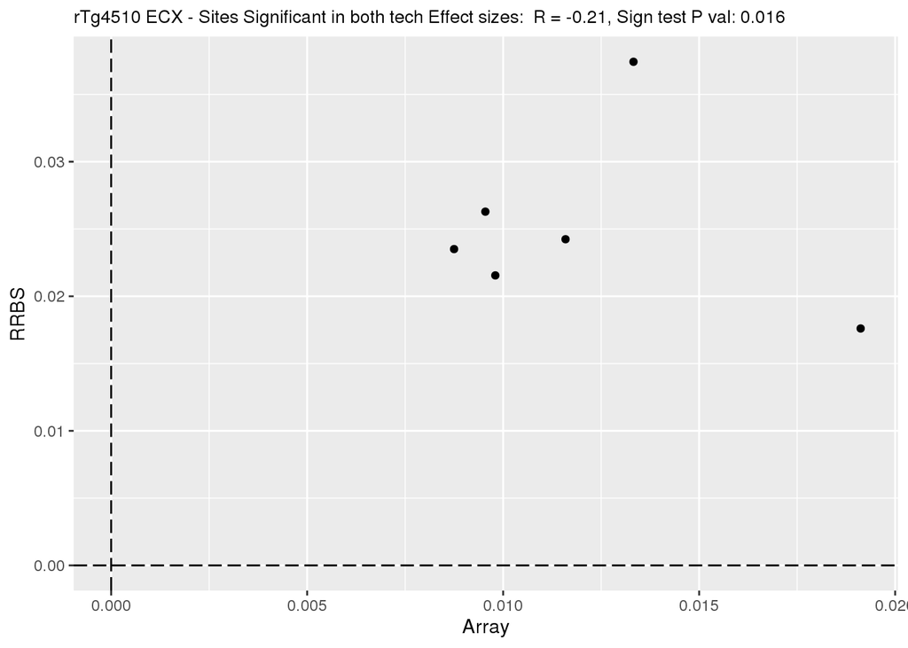

# Sites that are significant in the array data

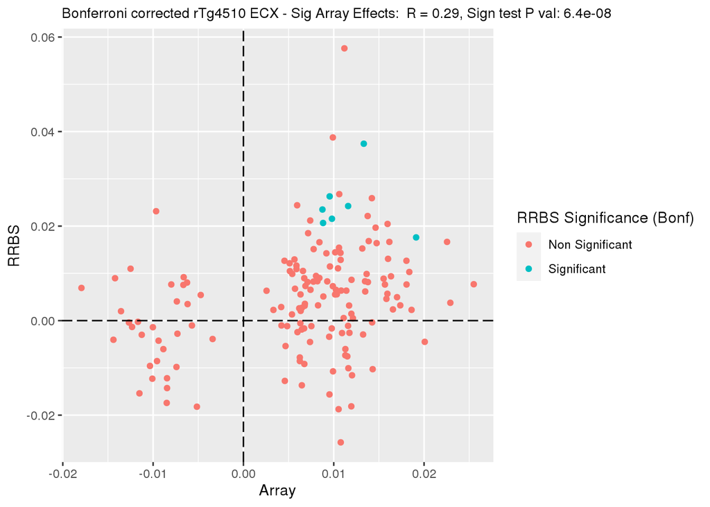

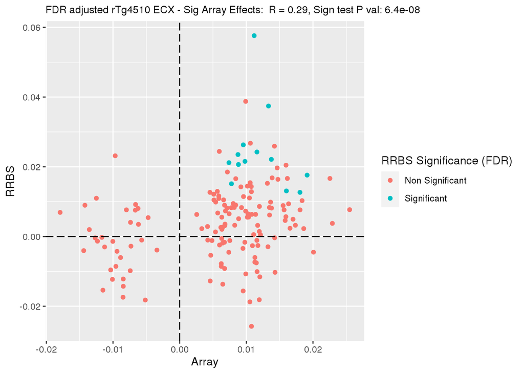

# Sites that are significant in the RRBS data

There are 15 sites which are significant for the RRBS data and have corresponding locations for the array data. 6 of the corresponding sites in the array data are significant using bonferonni correction and 8 using FDR adjustment.

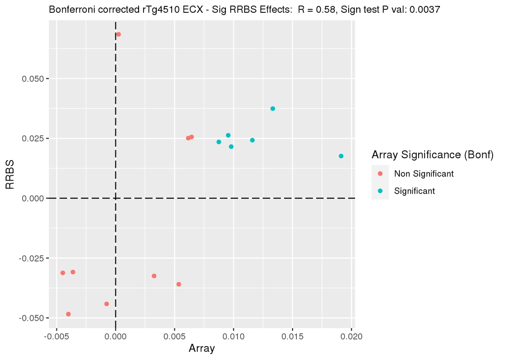

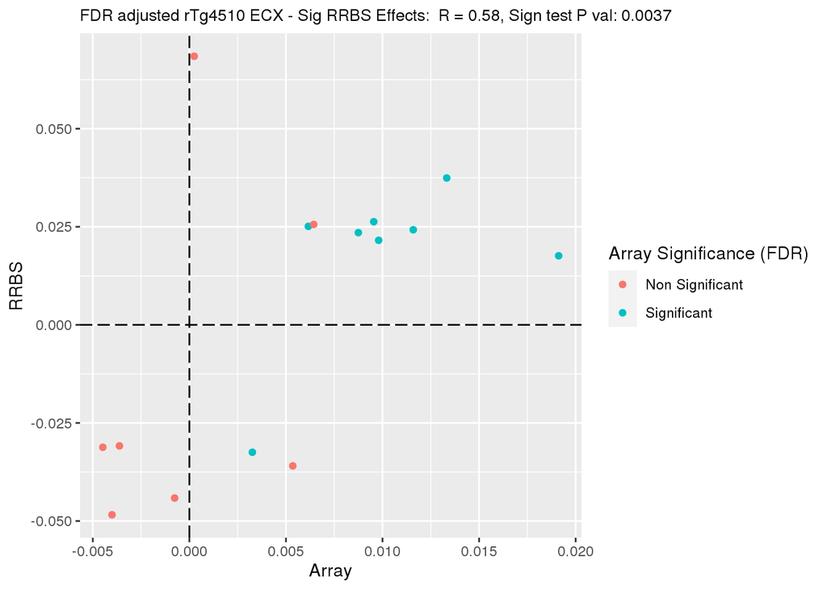

## Significant array sites and RRBS sites +/-100bp

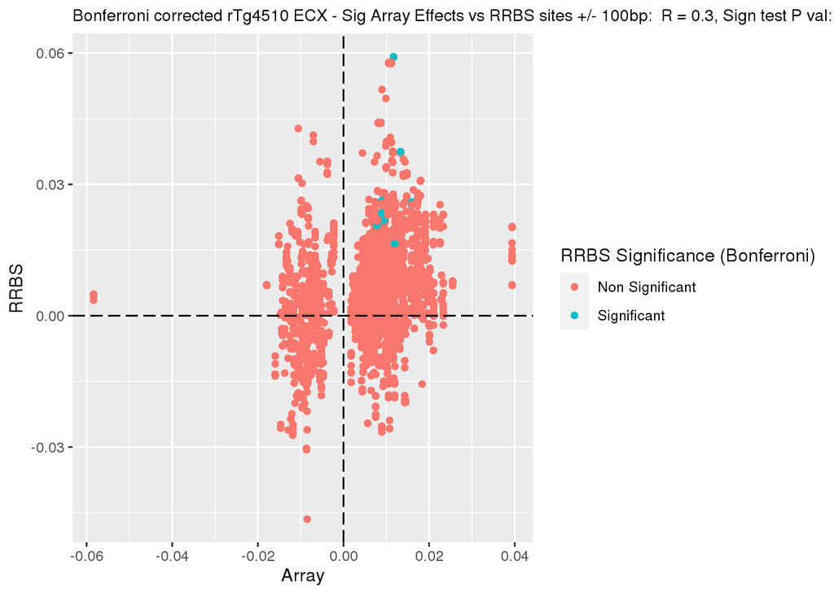

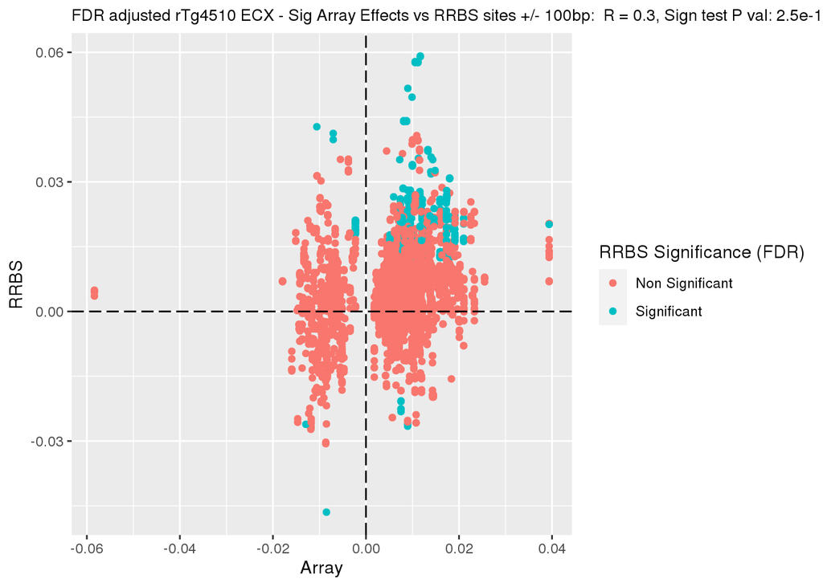

There are 510 significant DMPSs on the array which have a RRBS postion within +/-100bp (2664 unique RRBS locations) totalling 3273 site pairs.

## Significant RRBS sites and array sites +/-100bp

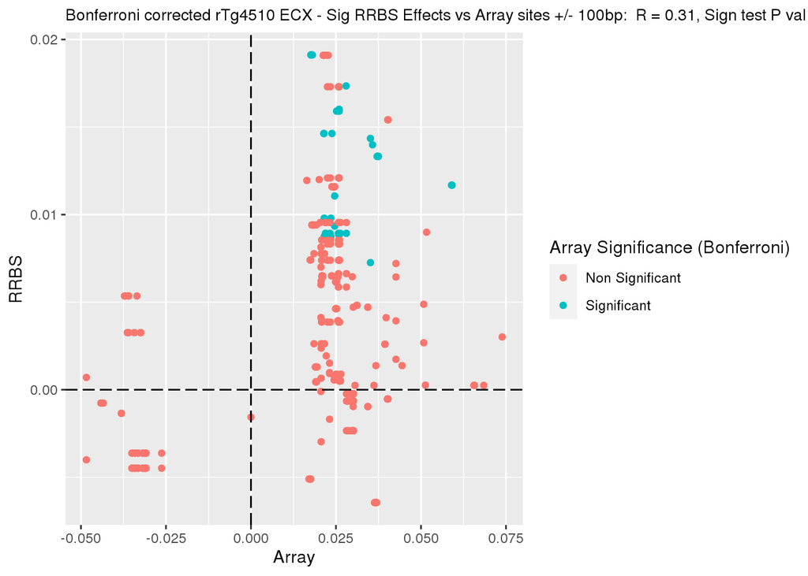

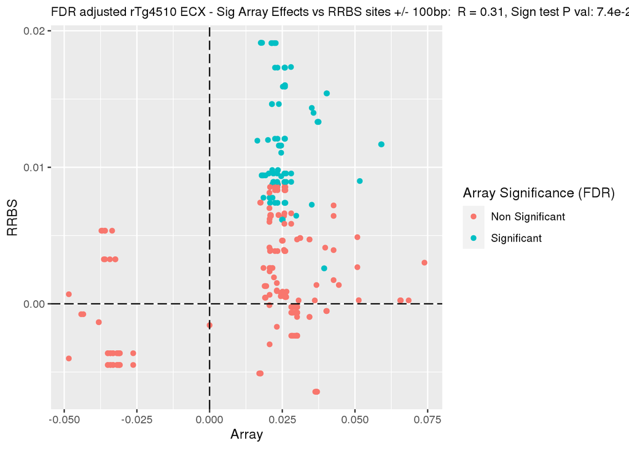

There are 176 significant DMPSs from the RRBS data which have an Array postion within +/-100bp (92 unique array locations) totalling 299 site pairs.

## Significant array sites that are within a significant RRBS DMR

None of the 2260 significant sites for pathology for the array data are within a pathology DMR (n=37)

## Gene level overlaps between the two technologies

There are 64 unique genes which contain at least one significant site/cpg from both the RRBS and array data.

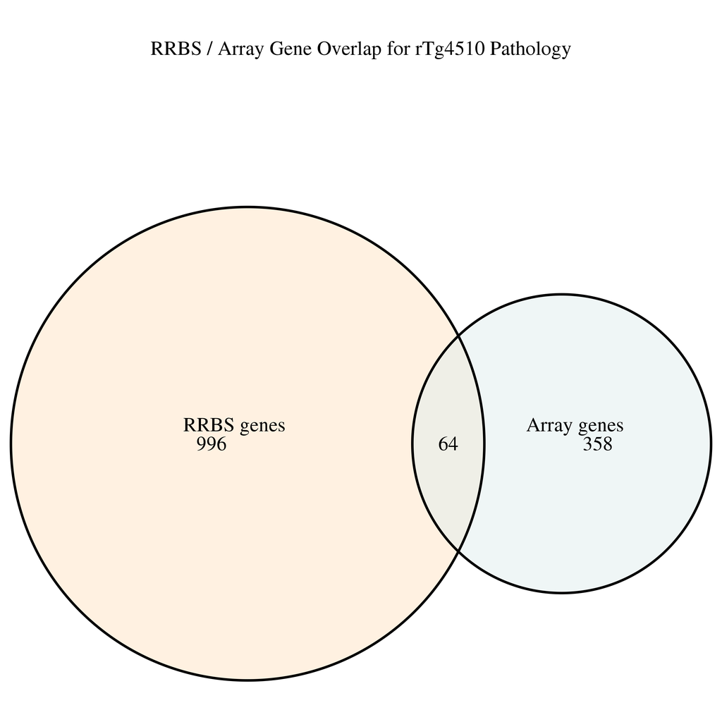